# assignR Examples

Gabe Bowen, Chao Ma

July 20, 2020

This vignette introduces the basic functionality of the *assignR* package using data bundled with the package. We’ll review how to access compiled data for known-origin biological samples and environmental models, use these to fit and apply functions estimating the probability of sample origin across a study region, and summarize these results to answer research and conservation questions. We’ll also demonstrate an assignment quality analysis tool useful in study design, method comparison, and uncertainty analysis.

Let’s install the package - This vignette version demos the latest features from the development version, which is installed via GitHub.

```r
library(devtools)
install_github("SPATIAL-Lab/assignR@*release")
```

Now let’s load it, along with a couple other packages we’ll need for the examples.

```r
library(assignR)
library(raster)
library(sp)
```

Now add some data from the package to your local environment. Load and plot the North America boundary mask.

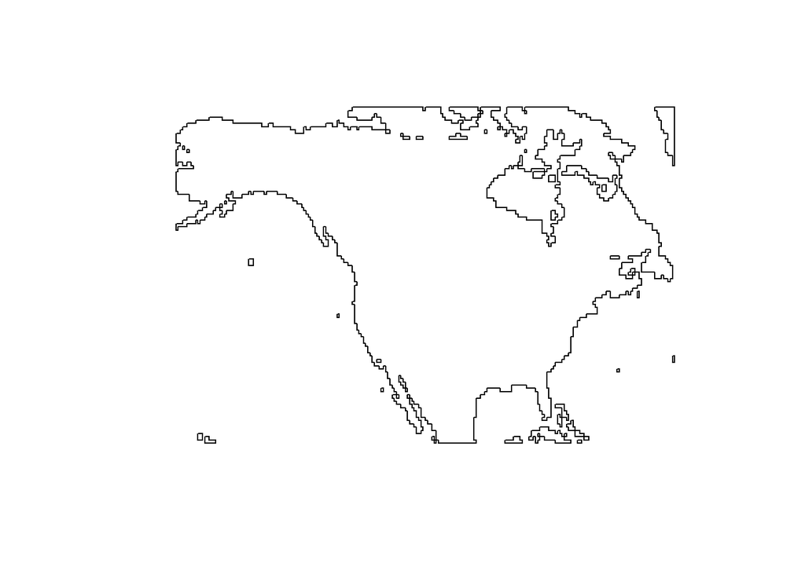

```r
data("naMap")
plot(naMap)
```

Load and plot a growing season precipitation H isoscape for North America. Notice this is a RasterBrick with two layers, the mean prediction and a standard deviation of the prediction. The layers are from [waterisotopes.org](http://wateriso.utah.edu/waterisotopes/), and resolution has been reduced to speed up processing in these examples. Full-resolution global growing season isoscapes are included in the package as *d2h_world.rda* and *d18o_world.rda*.

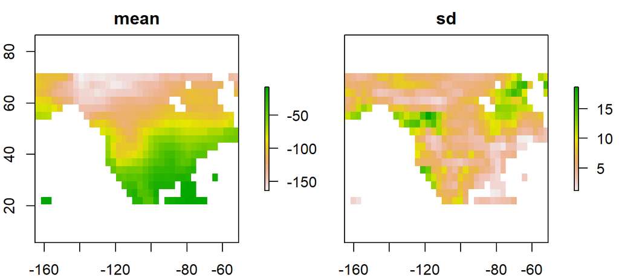

```r
data("d2h_lrNA")
plot(d2h_lrNA)
```

The package includes a database of H and O isotope data for known origin samples, which consists of three tables (*knownOrig_sites.rda*, *knownOrig_samples.rda*, and *knownOrig_sources.rda*). Let’s load it and have a look. First we’ll get the names of the data fields available in the tables.

```r
data("knownOrig_sites", "knownOrig_samples", "knownOrig_sources")
names(knownOrig_sites)
```

```
## [1] "Site_ID"       "Site_name"     "State"         "Country"
## [5] "Site_comments"
```

```r
names(knownOrig_samples)
```

```
##  [1] "Sample_ID"       "Sample_ID_orig"  "Site_ID"         "Dataset_ID"
##  [5] "Taxon"           "Group"           "Source_quality"  "Age_class"
##  [9] "Material_type"   "Matrix"          "d2H"             "d2H.sd"
## [13] "d18O"            "d18O.sd"         "Sample_comments"
```

```r
names(knownOrig_sources)
```

```
##  [1] "Dataset_ID"              "Dataset_name"
##  [3] "Citation"                "Sampling_method"
##  [5] "Sample_powdered"         "Lipid_extraction"
##  [7] "Lipid_extraction_method" "Exchange"
##  [9] "Exchange_method"         "Exchange_T"
## [11] "H_cal"                   "O_cal"
## [13] "Std_powdered"            "Drying"
## [15] "Analysis_method"         "Analysis_type"
## [17] "Source_comments"
```

Now lets look at a list of species names available.

```r
unique(knownOrig_samples$Taxon)
```

```
##  [1] "Danaus plexippus"            "Setophaga ruticilla"
##  [3] "Turdus migratorius"          "Setophaga coronata auduboni"
##  [5] "Poecile atricapillus"        "Thryomanes bewickii"
##  [7] "Thryothorus ludovicianus"    "Spizella passerina"
##  [9] "Geothlypis trichas"          "Setophaga pensylvanica"
## [11] "Baeolophus bicolor"          "Vermivora chrysoptera"
## [13] "Catharus guttatus"           "Setophaga citrina"
## [15] "Geothlypis formosa"          "Geothlypis tolmiei"
## [17] "Oreothlypis ruficapilla"     "Cardinalis cardinalis"
## [19] "Oreothlypis celata"          "Junco hyemalis oregonus"
## [21] "Seiurus aurocapilla"         "Vireo olivaceus"
## [23] "Melospiza melodia"           "Catharus ustulatus"
## [25] "Catharus fuscescens"         "Vireo griseus"
## [27] "Cardellina pusilla"          "Hylocichla mustelina"
## [29] "Icteria virens"              "Setophaga petechia"
```

[output cut: 30 more lines]

Load H isotope data for North American Loggerhead Shrike from the package database.

```r
d = subOrigData(taxon = "Lanius ludovicianus", mask = naMap)
```

```
## 524 samples are found from 427 sites
```

```
## 524 samples from 427 sites in the transformed dataset
```

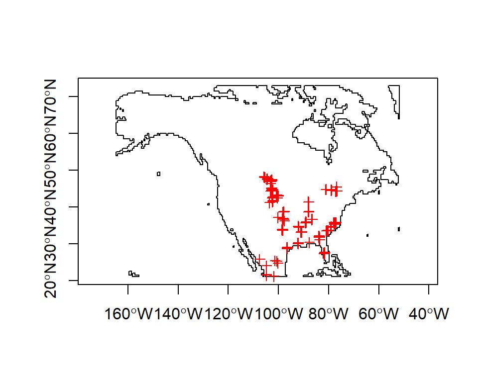

By default, the *subOrigData* function transforms all data to a common calibration scale (VSMOW-SLAP), using data from co-analysis of different laboratory reference materials (Magozzi et al., in prep). The co-analysis comparisons used are documented in the function’s return object.

```r
d$chains
```

```
## [[1]]
## [1] "OldSA.1_H_1" "SA_H_6"      "SA_H_7"      "VSMOW_H"
```

Information on these calibration scales is contained in the *hrms.rda* and *orms.rda* data files.

Transformation is important when blending data from different labs or papers because different reference materials have been used to calibrate published data and these calibrations are not always comparable. In this case all the data come from one paper:

```r
d$sources[,1:3]
```

```
##   Dataset_ID            Dataset_name
## 2          2 Hobson et al. 2012 Plos
##                                                                                                                                                                                                         Citation
## 2 Hobson KA, Van Wilgenburg SL, Wassenaar LI, Larson K. 2012. Linking hydrogen (d2H) isotopes in feathers and precipitation: sources of variance and consequences for assignment to isoscapes. Plos One 7:e35137
```

If we didn’t want to transform the data, and instead wished to use the calibration scale from the original publication, we can specify that in our call to *subOrigData*. Keep in mind that any subsequent analyses using these data will be based on this calibration scale: for example, if you wish to assign samples of unknown origin, the values for those samples should be reported on the same scale.

```r
d = subOrigData(taxon = "Lanius ludovicianus", mask = naMap, ref_scale = NULL)
```

```
## 524 samples are found from 427 sites
```

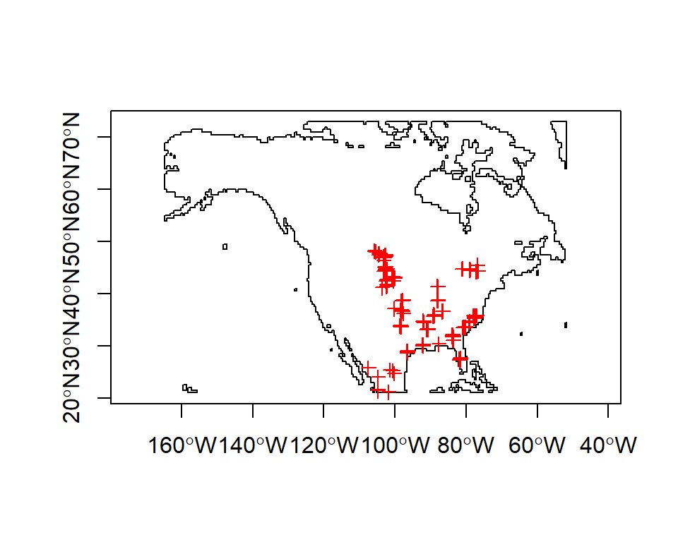

```r
d$sources$H_std_scale
```

[output not shown]

For a real application you would want to explore the database to find measurements that are appropriate to your study system (same or similar taxon, geographic region, measurement approach, etc.) or collect and import known-origin data that are specific to your system.

# Isoscape Calibration and Probability of Origin for Unknown Samples

We need to start by assessing how the environmental (precipitation) isoscape values correlate with the sample values. *calRaster* fits a linear model relating the precipitation isoscape values to sample values, and applies it to produce a sample-type specific isoscape.

```r
r = calRaster(known = d, isoscape = d2h_lrNA, mask = naMap)
```

```
##
##
## ---------------------------------------
##         ------------------------------------------
## rescale function uses linear regression model,
##         the summary of this model is:
## -------------------------------------------
##         --------------------------------------
##
## Call:
## lm(formula = tissue.iso ~ isoscape.iso[, 1], weights = tissue.iso.wt)
##
## Residuals:
##      Min       1Q   Median       3Q      Max
## -148.787  -16.584    0.353   19.239  107.727
##
## Coefficients:
##                   Estimate Std. Error t value Pr(>|t|)
## (Intercept)        0.92452    1.77787    0.52    0.603
## isoscape.iso[, 1]  1.11204    0.03966   28.04   <2e-16 ***
## ---
## Signif. codes:  0 '***' 0.001 '**' 0.01 '*' 0.05 '.' 0.1 ' ' 1
##
## Residual standard error: 32.4 on 522 degrees of freedom
## Multiple R-squared:  0.601,  Adjusted R-squared:  0.6002
## F-statistic: 786.2 on 1 and 522 DF,  p-value: < 2.2e-16
```

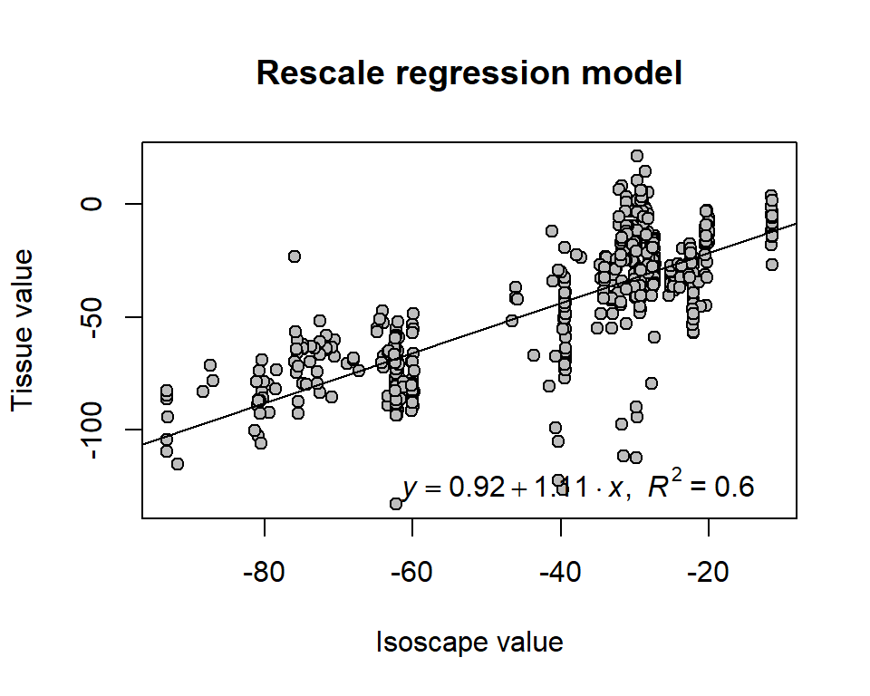

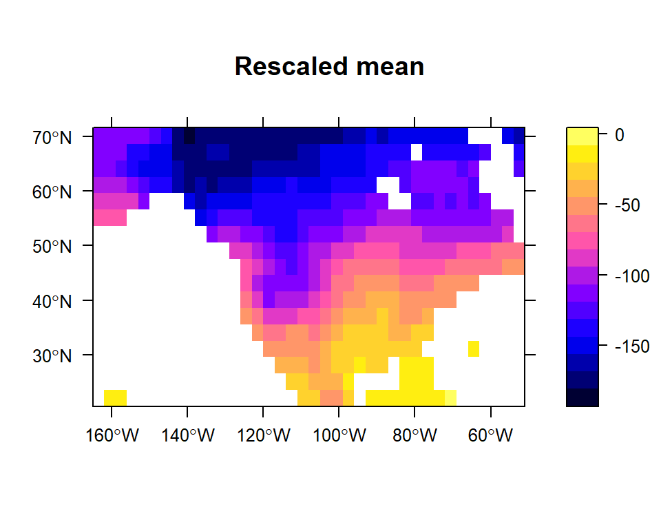

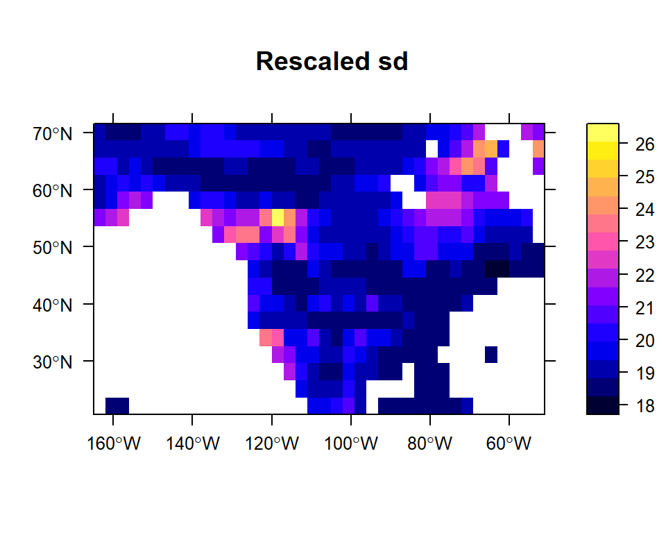

Let’s create some hypothetical sample IDs and values to demonstrate how samples of unknown origin can be assigned to the calibrated isoscape. The isotope values are drawn from a random distribution with a standard deviation of 8 per mil, which is a pretty reasonable variance for conspecific residents at a single location. We’ll also add made-up values for the analytical uncertainty for each sample and a column recording the calibration scale used for our measurements (see below). If you had real measured data for your study samples you would load them here, instead.

```r
id = letters[1:5]
set.seed(123)
d2H = rnorm(5, -110, 8)
d2H.sd = runif(5, 1.5, 2.5)
d2H_cal = rep("UT_H_1", 5)
un = data.frame(id, d2H, d2H.sd, d2H_cal)
print(un)
```

```
##   id        d2H   d2H.sd d2H_cal
## 1  a -114.48381 2.456833  UT_H_1
## 2  b -111.84142 1.953334  UT_H_1
## 3  c  -97.53033 2.177571  UT_H_1
## 4  d -109.43593 2.072633  UT_H_1
## 5  e -108.96570 1.602925  UT_H_1
```

As discussed above, one issue that must be considered with any organic H or O isotope data is the calibration scale (the reference materials and assigned, calibrated values for those) used by the laboratory producing the data. The calibration scale for your unknown samples should be the same as that for the known origin data used in calRaster. Remember that the scale for our known origin data ‘d’ is *OldSA.1_H_1*. Let’s assume that our fake data were normalized to the *UT_H_1* scale. The *refTrans* function allows us to convert between the two.

```r
un = refTrans(un, ref_scale = "OldSA.1_H_1")
print(un)
```

```
## $data
##   id       d2H   d2H.sd     d2H_cal
## 1  a -126.6790 2.751135 OldSA.1_H_1
## 2  b -123.7849 2.384648 OldSA.1_H_1
## 3  c -108.6322 2.373614 OldSA.1_H_1
## 4  d -121.2054 2.361301 OldSA.1_H_1
## 5  e -120.6225 2.015969 OldSA.1_H_1
##
## $chains
## $chains[[1]]
## [1] "UT_H_1"      "UT_H_2"      "US_H_5"      "US_H_7"      "VSMOW_H"
## [6] "SA_H_7"      "SA_H_6"      "OldSA.1_H_1"
```

Notice that both the d2H values and the uncertainties have been updated to reflect the scale transformation.

Produce posterior probability density maps used to the assign the unknown origin samples. For reference on the Bayesian inversion method see [Wunder, 2010](https://www.researchgate.net/profile/Michael_Wunder/publication/226054272_Using_Isoscapes_to_Model_Probability_Surfaces_for_Determining_Geographic_Origins/links/00b49526ab1e02ed11000000.pdf)

```r
asn = pdRaster(r, unknown = un$data)
```

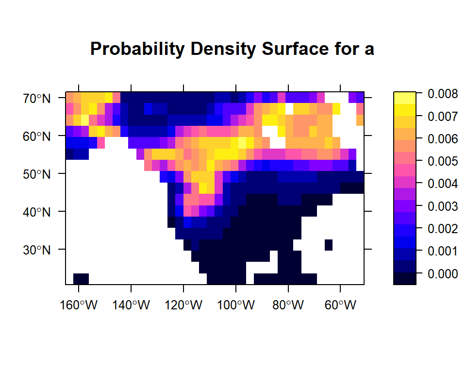

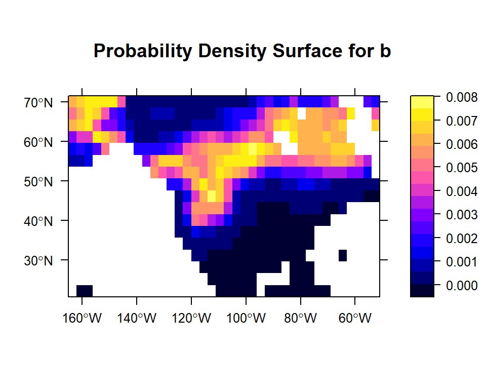

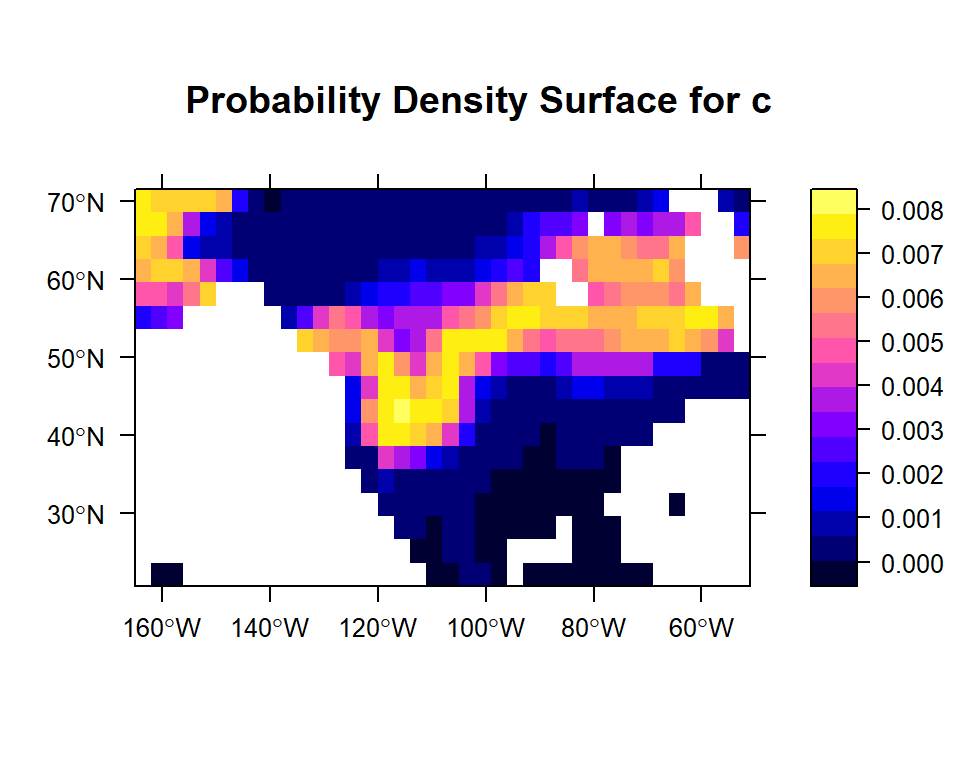

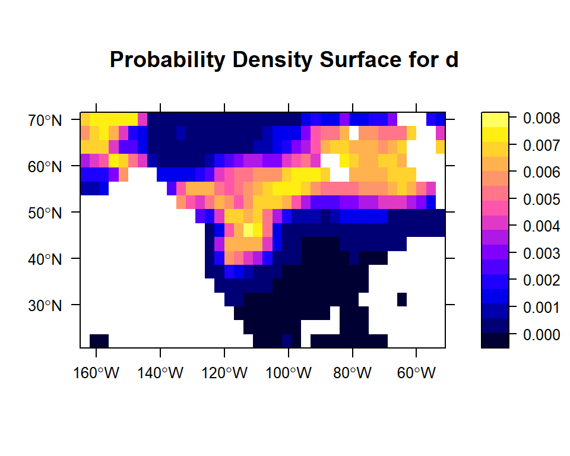

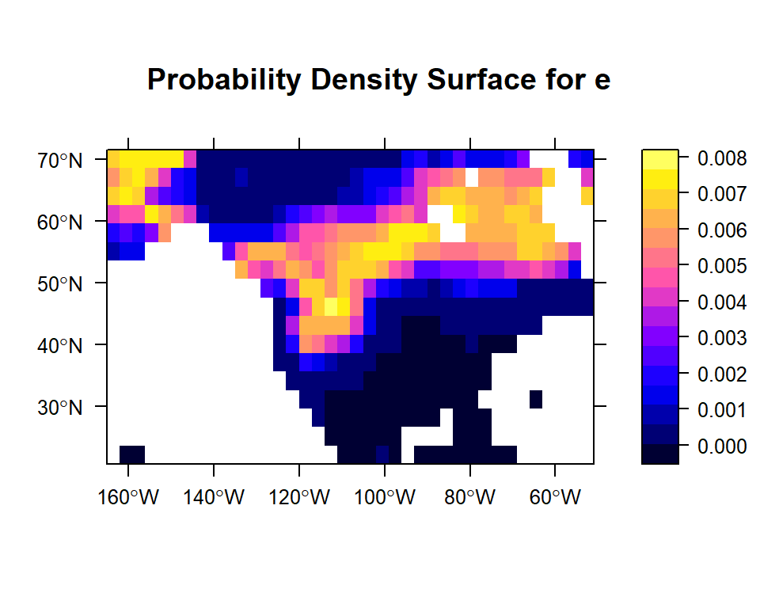

Cell values in these maps are small because each cell’s value represents the probability that this one cell, out of all of them on the map, is the actual origin of the sample. Together, all cell values on the map should sum to ‘1’, reflecting the assumption that the sample originated *somewhere* in the study area. Let’s check this for sample ‘a’.

```r
cellStats(asn[[1]], 'sum')
```

```
## [1] 1
```

Check out the help page for *pdRaster* for additional options, including the use of informative prior probabilities.

# Post-hoc Analysis

## Odds Ratio

The *oddsRatio* tool compares the posterior probabilities for two different locations or regions. This might be useful in answering real-world questions…for example “is this sample more likely from France or Spain?”, or “how likely is this hypothesized location relative to other possibilities?”.

Let’s compare probabilities for two spatial areas - the states of Utah and New Mexico. First we’ll load the SpatialPolygons and plot them.

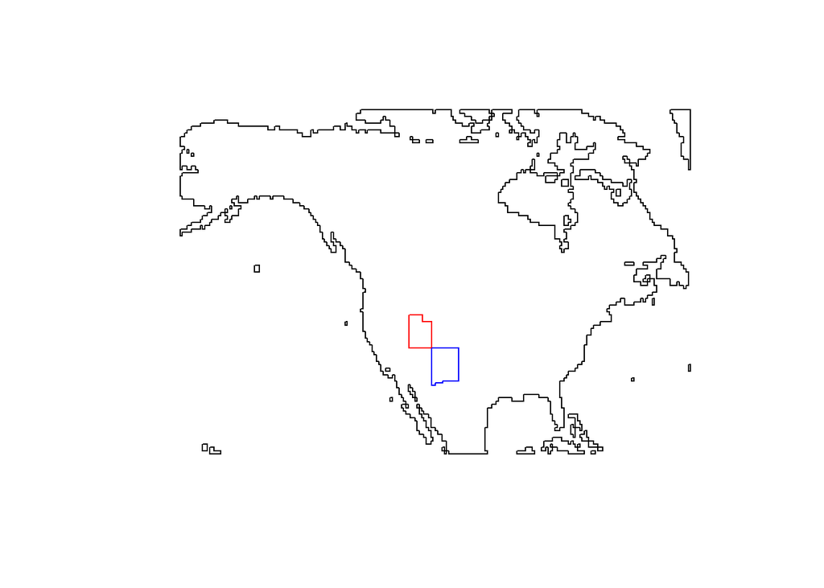

```r
data("states")
s1 = states[states$STATE_ABBR == "UT",]
s2 = states[states$STATE_ABBR == "NM",]
plot(naMap)
lines(s1, col = c("red"))
lines(s2, col = c("blue"))
```

Get the odds ratio for the two regions. The result reports the odds ratio for the regions (first relative to second) for each of the 5 unknown samples plus the ratio of the areas of the regions. If the isotope values (& prior) were completely uninformative the odds ratios would equal the ratio of areas.

```r
s12 = rbind(s1, s2)
oddsRatio(asn, s12)
```

```
## $`P1/P2 odds ratio`
##        a        b        c        d        e
## 502.4522 365.1073  71.7047 275.2158 258.2563
##
## $`Ratio of numbers of cells in two polygons`
## [1] 2
```

Comparisons can also be made using points. Let’s create two points (one in each of the Plover regions) and compare their odds. This result also shows the odds ratio for each point relative to the most- and least-likely grid cells on the posterior probability map.

```r
pp1 = c(-112,40)
pp2 = c(-105,33)
pp12 = SpatialPoints(coords = rbind(pp1,pp2))
proj4string(pp12) = proj4string(naMap)
oddsRatio(asn, pp12)
```

```
## $`P1/P2 odds ratio`
##         a         b         c         d         e
## 2611.1793 1696.5175  177.6924 1155.2803 1059.2011
##
## $`Odds relative to the max/min pixel`
##    ratioToMax.a ratioToMax.b ratioToMax.c ratioToMax.d ratioToMax.e
## P1 0.3641839534 0.4256366369   0.91138281  0.527529438 0.5361161204
## P2 0.0001402272 0.0002599558   0.00525824  0.000435759 0.0005072174
##    ratioToMin.a ratioToMin.b ratioToMin.c ratioToMin.d ratioToMin.e
## P1 428919057.33   1432907.94    137213223 2.271214e+08  97949229.51
## P2     60373.11     47494.32      6192912 1.466985e+03     76364.11
```

The odds of the first point being the location of origin are pretty high for each sample, and much higher than for the second point.

## Assignment

Researchers often want to classify their study area in to regions that are and are not likely to be the origin of the sample (effectively ‘assigning’ the sample to a part of the area). This requires choosing a subjective threshold to define how much of the study domain is represented in the assignment region. *qtlRaster* offers two choices.

Extract 10% of the study area, giving maps that show the 10% of grid cells with the highest posterior probability for each sample.

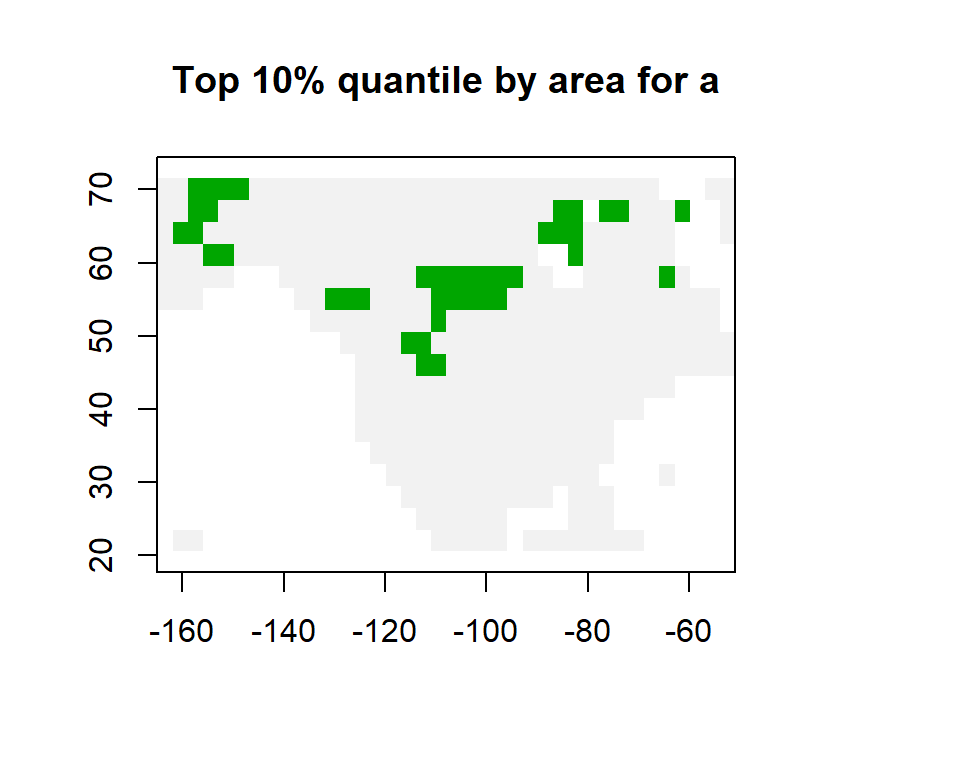

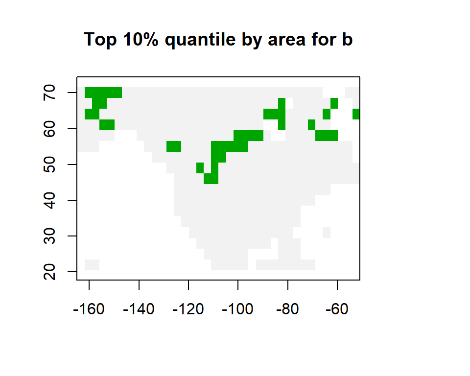

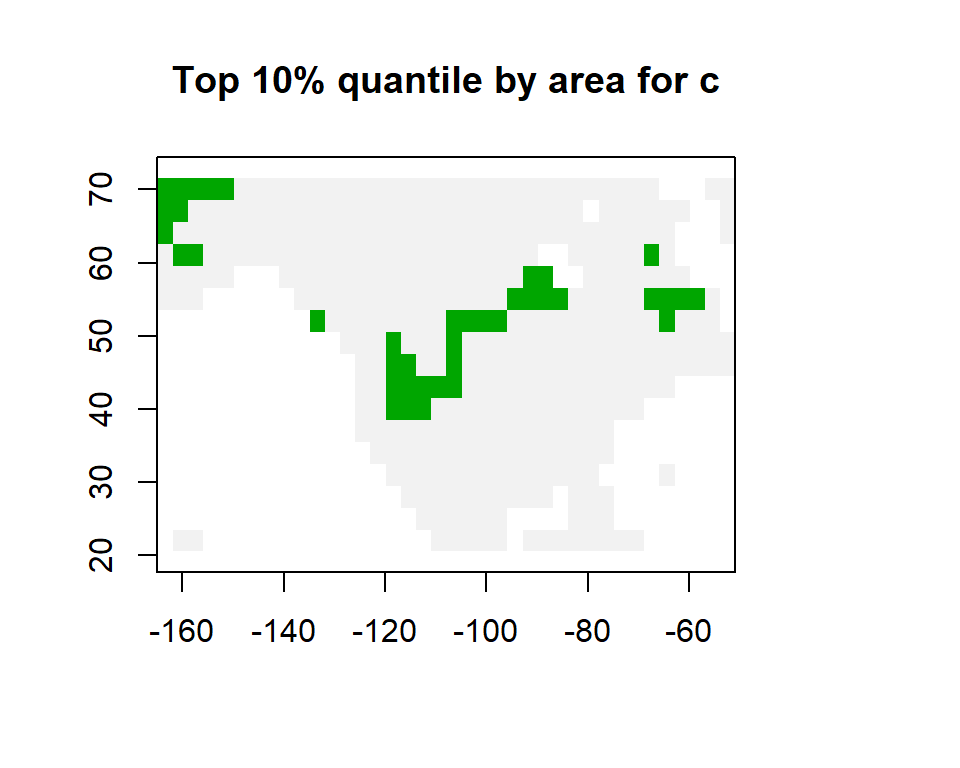

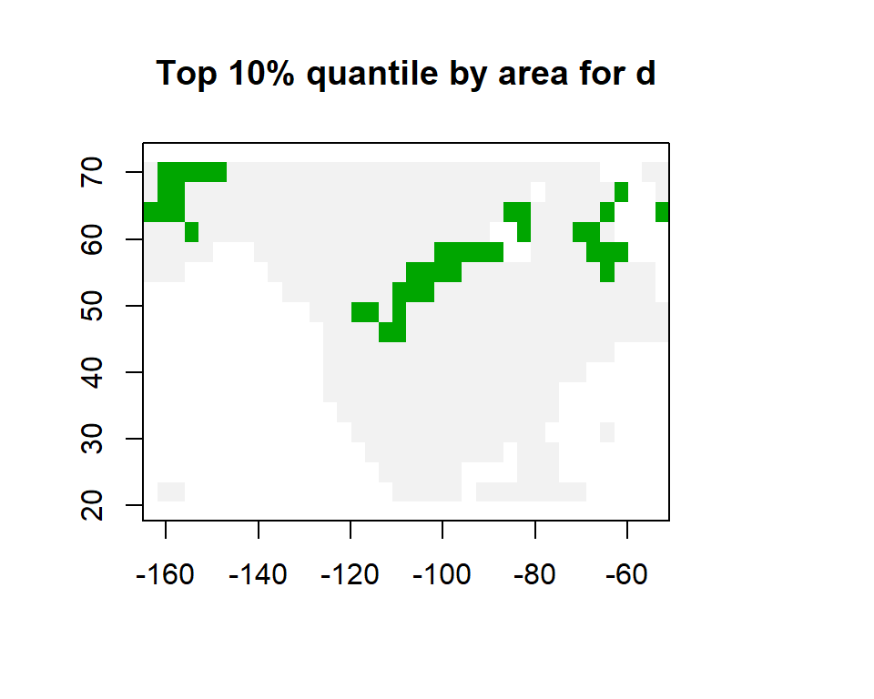

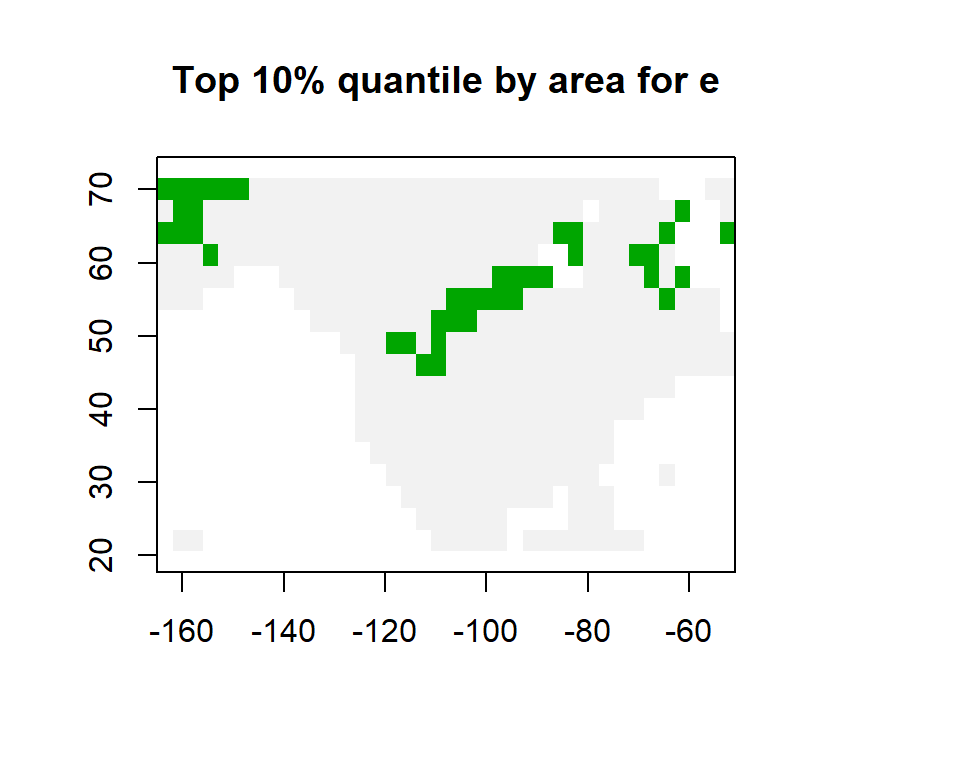

```
## class      : RasterStack
## dimensions : 17, 38, 646, 5  (nrow, ncol, ncell, nlayers)
## resolution : 2.999999, 2.999999  (x, y)
## extent     : -165, -51.00005, 20.58329, 71.58327  (xmin, xmax, ymin, ymax)
## crs        : +proj=longlat +ellps=WGS84 +towgs84=0,0,0,0,0,0,0 +no_defs
## names      : a, b, c, d, e
## min values : 0, 0, 0, 0, 0
## max values : 1, 1, 1, 1, 1
```

```r
qtlRaster(asn, threshold = 0.1)
```

Extract 80% of the posterior probability density, giving maps that show the smallest region within which there is an 80% chance each sample originated.

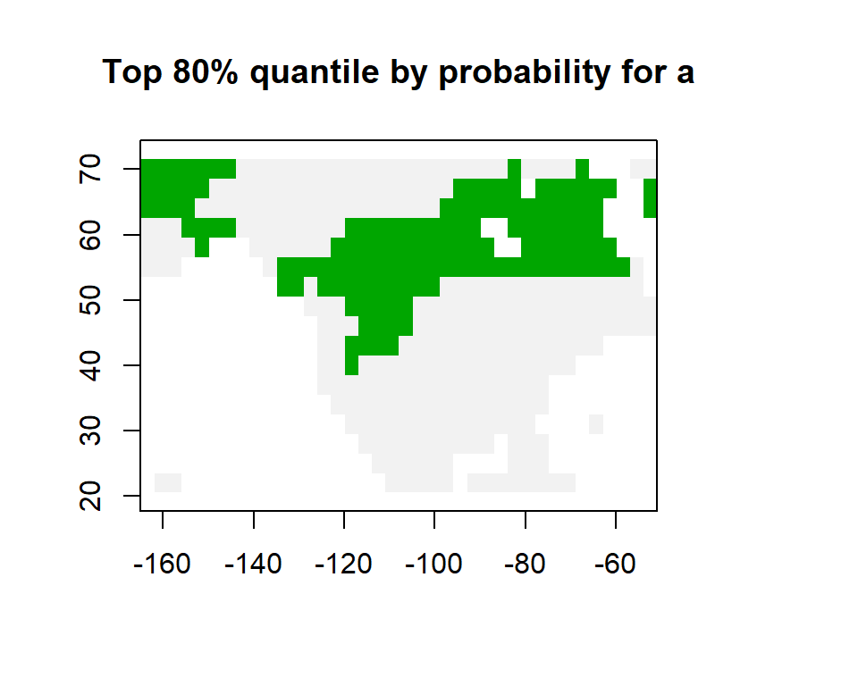

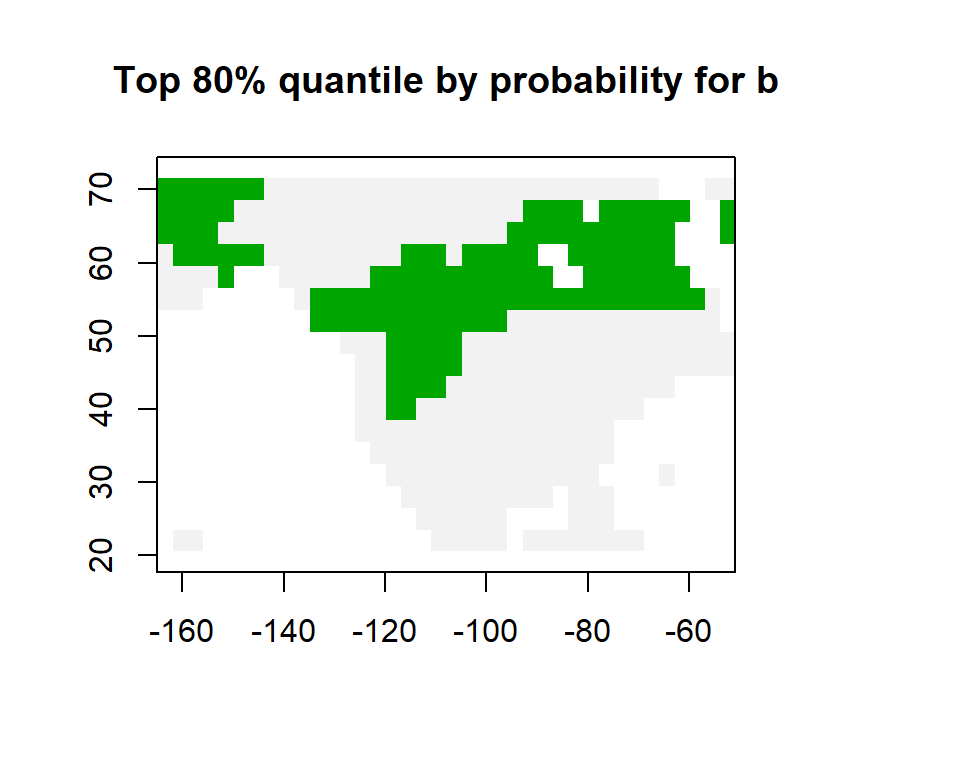

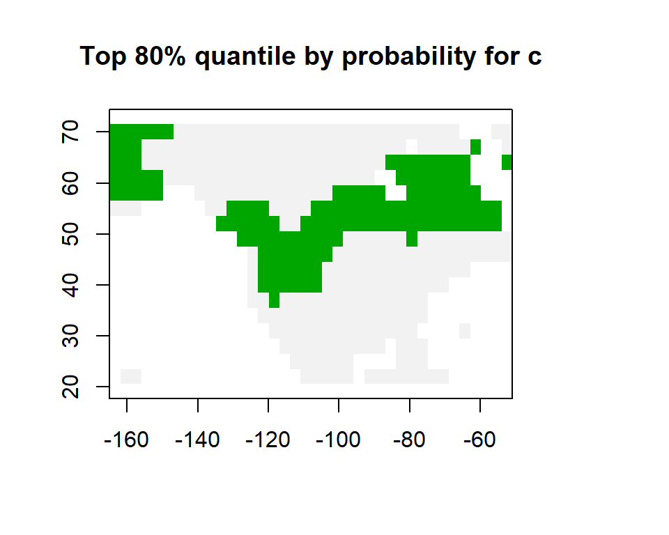

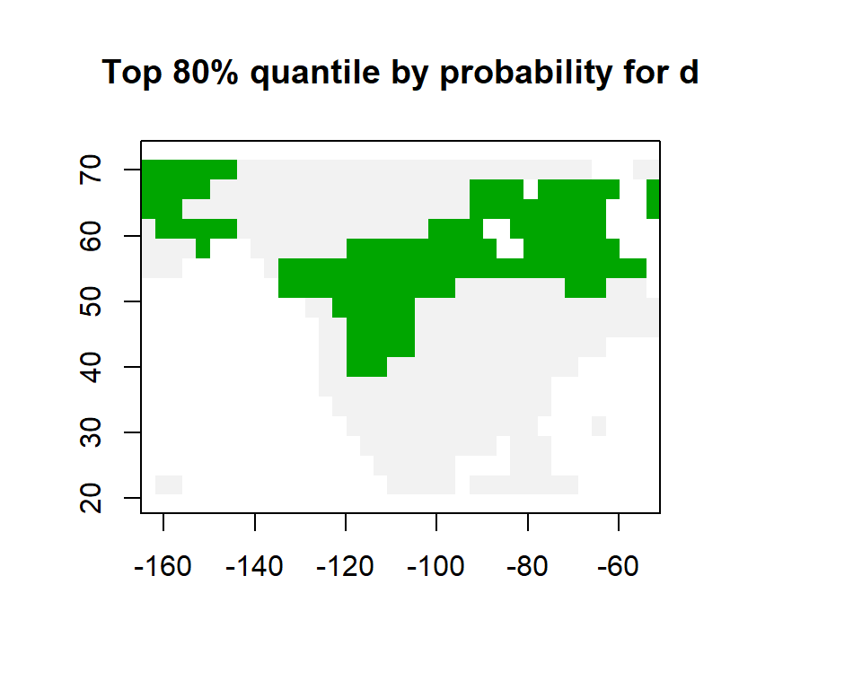

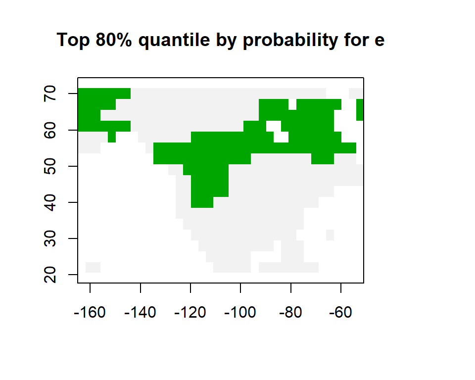

```
## class      : RasterStack
## dimensions : 17, 38, 646, 5  (nrow, ncol, ncell, nlayers)
## resolution : 2.999999, 2.999999  (x, y)
## extent     : -165, -51.00005, 20.58329, 71.58327  (xmin, xmax, ymin, ymax)
## crs        : +proj=longlat +ellps=WGS84 +towgs84=0,0,0,0,0,0,0 +no_defs
## names      : a, b, c, d, e
## min values : 0, 0, 0, 0, 0
## max values : 1, 1, 1, 1, 1
```

```r
qtlRaster(asn, threshold = 0.8, thresholdType = "prob")
```

Comparing the two results, the probability-based assignment regions are broader. This suggests that we’ll need to assign to more than 10% of the study area if we want to correctly assign 80% or more of our samples. We’ll revisit this below and see how we can chose thresholds that are as specific as possible while achieving a desired level of assignment ‘quality’.

## Summarization

Most studies involve assigning multiple individuals, and often it is desirable to summarize the results from these individuals. *jointP* and *unionP* offer two options for summarizing posterior probabilities from multiple samples.

Calculate the probability that **all** samples came from any given grid cell in the analysis area. Note that this summarization will only be useful if all samples are truly derived from a single population of common geographic origin.

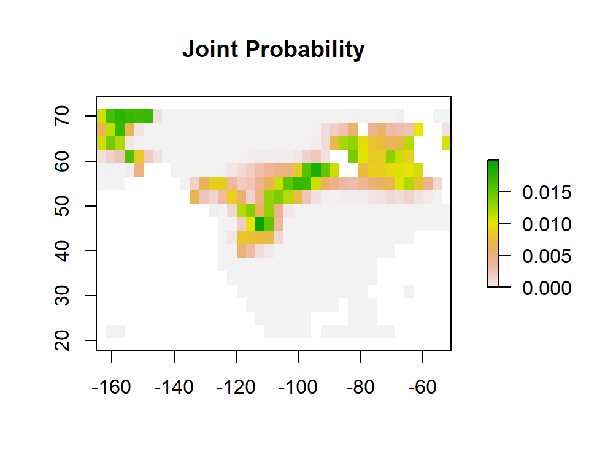

```
## class      : RasterLayer
## dimensions : 17, 38, 646  (nrow, ncol, ncell)
## resolution : 2.999999, 2.999999  (x, y)
## extent     : -165, -51.00005, 20.58329, 71.58327  (xmin, xmax, ymin, ymax)
## crs        : +proj=longlat +ellps=WGS84 +towgs84=0,0,0,0,0,0,0 +no_defs
## source     : memory
## names      : Joint_Probability
## values     : 5.287142e-43, 0.01991789  (min, max)
```

```r
jointP(asn)
```

Calculate the probability that **any** sample came from any given grid cell in the analysis area. In this case we’ll save the output to a variable for later use.

```r
up = unionP(asn)
```

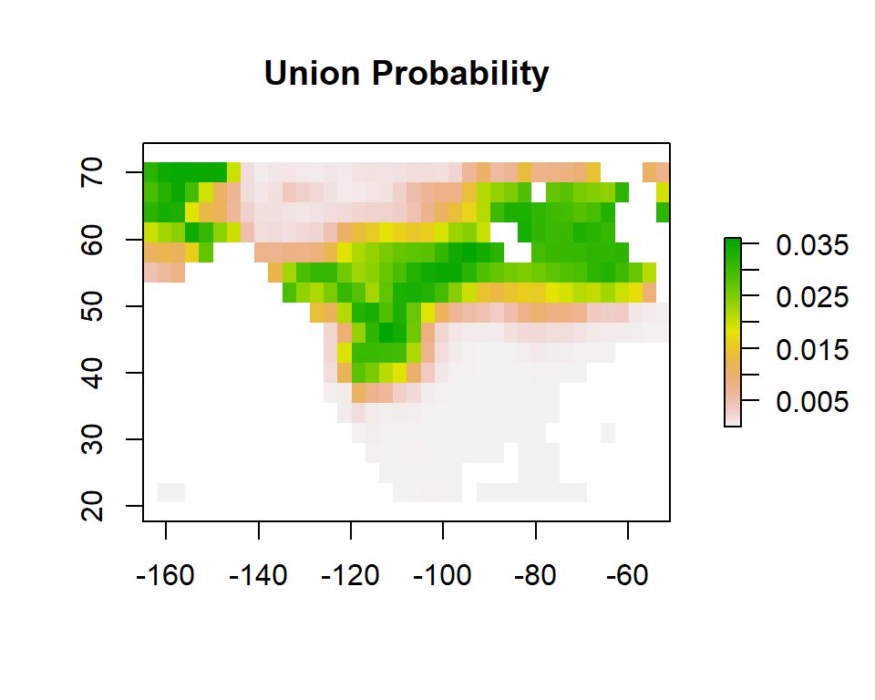

The results from *unionP* highlight a broader region, as you might expect.

Any of the other post-hoc analysis tools can be applied to the summarized results. Here we’ll use *qtlRaster* to identify the 10% of the study area that is most likely to be the origin of one or more samples.

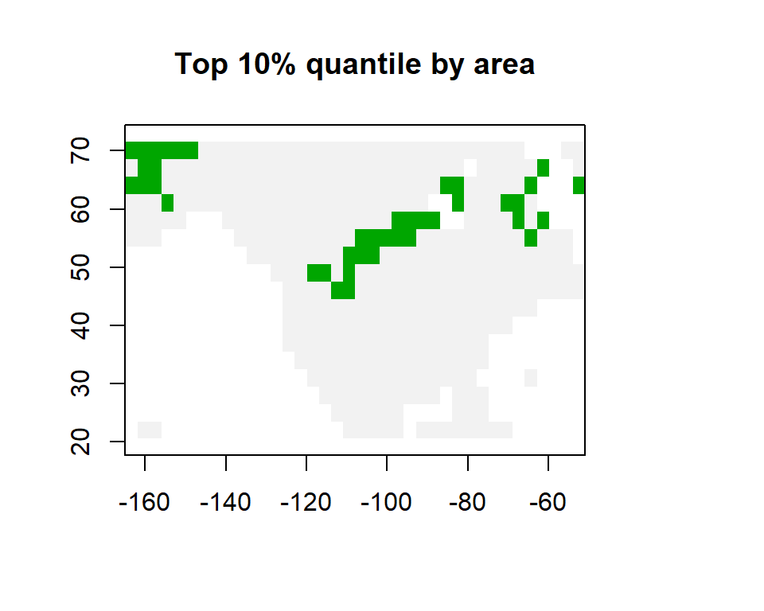

```
## class      : RasterLayer
## dimensions : 17, 38, 646  (nrow, ncol, ncell)
## resolution : 2.999999, 2.999999  (x, y)
## extent     : -165, -51.00005, 20.58329, 71.58327  (xmin, xmax, ymin, ymax)
## crs        : +proj=longlat +ellps=WGS84 +towgs84=0,0,0,0,0,0,0 +no_defs
## source     : memory
## names      : layer
## values     : 0, 1  (min, max)
```

```r
qtlRaster(up, threshold = 0.1)
```

## Quality analysis and method comparison

How good are the geographic assignments? What area or probability threshold should be used? Is it better to use isoscape *A* or *B* for my analysis? These questions can be answered through split-sample validation using *QA*.

We will run quality assessment on the known-origin dataset and precipitation isoscape. These analyses take some time to run, depending on the number of stations and iterations used (this one took about two minutes on my desktop PC).

```r
qa1 = QA(d, d2h_lrNA, valiStation = 8, valiTime = 4, by = 5, mask = naMap, name = "normal")
```

Plot the result. (Please note that because of changes in R’s random number generator your results may not exactly match those shown here if you are using R version 3.5.X.)

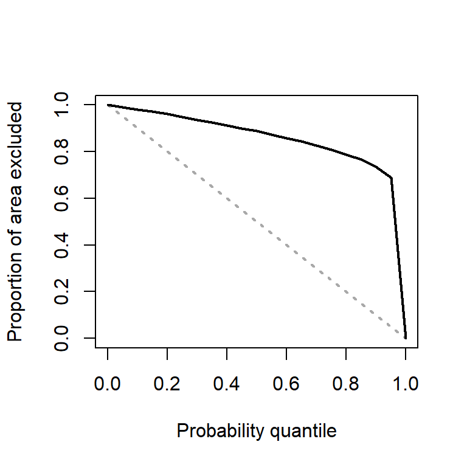

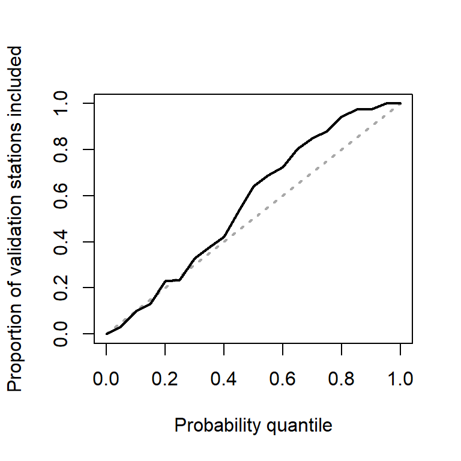

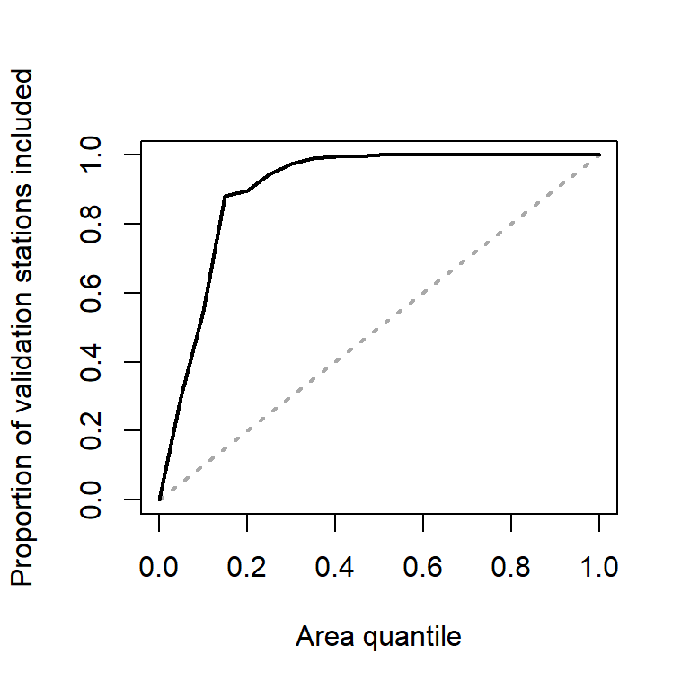

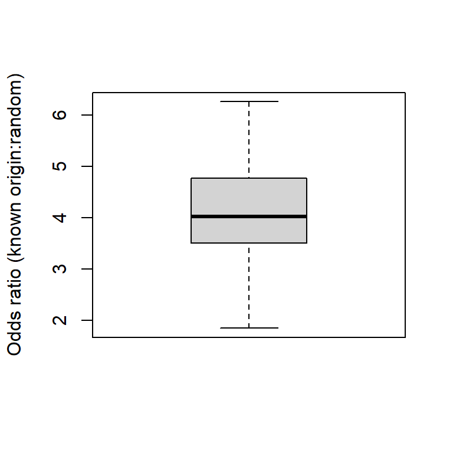

```r
plot(qa1)
```

How would using a different isoscape or different known origin dataset affect the analysis? Multiple QA objects can be compared to make these types of assessments.